# PSTAT 131 HW 5

Ezra Aguimatang

2022-11-20

## Elastic Net Tuning

For this assignment, we will be working with the file `"pokemon.csv"`, found in `/131_HW_5_Data`. The file is from Kaggle: https://www.kaggle.com/abcsds/pokemon.

The [Pokémon](https://www.pokemon.com/us/) franchise encompasses video games, TV shows, movies, books, and a card game. This data set was drawn from the video game series and contains statistics about 721 Pokémon, or “pocket monsters.” In Pokémon games, the user plays as a trainer who collects, trades, and battles Pokémon to (a) collect all the Pokémon and (b) become the champion Pokémon trainer.

Each Pokémon has a [primary type](https://bulbapedia.bulbagarden.net/wiki/Type) (some even have secondary types). Based on their type, a Pokémon is strong against some types, and vulnerable to others. (Think rock, paper, scissors.) A Fire-type Pokémon, for example, is vulnerable to Water-type Pokémon, but strong against Grass-type.

The goal of this assignment is to build a statistical learning model that can predict the **primary type** of a Pokémon based on its generation, legendary status, and six battle statistics.

Read in the file and familiarize yourself with the variables using `pokemon_codebook.txt`.

```r
pokemon_df <- read.csv("131_HW_5_Data/Pokemon.csv", header=TRUE)
head(pokemon_df)
```

```
##   X.                  Name Type.1 Type.2 Total HP Attack Defense Sp..Atk
## 1  1             Bulbasaur  Grass Poison   318 45     49      49      65
## 2  2               Ivysaur  Grass Poison   405 60     62      63      80
## 3  3              Venusaur  Grass Poison   525 80     82      83     100
## 4  3 VenusaurMega Venusaur  Grass Poison   625 80    100     123     122
## 5  4            Charmander   Fire          309 39     52      43      60
## 6  5            Charmeleon   Fire          405 58     64      58      80
##   Sp..Def Speed Generation Legendary
## 1      65    45          1     False
## 2      80    60          1     False
## 3     100    80          1     False
## 4     120    80          1     False
## 5      50    65          1     False
## 6      65    80          1     False
```

### Exercise 1

Install and load the `janitor` package. Use its `clean_names()` function on the Pokémon data, and save the results to work with for the rest of the assignment. What happened to the data? Why do you think `clean_names()` is useful?

## Solution 1:

```r
pokedex <- as_tibble(pokemon_df) %>%
  clean_names()
head(pokedex)
```

```
## # A tibble: 6 × 13
##       x name        type_1 type_2 total    hp attack defense sp_atk sp_def speed
##   <int> <chr>       <chr>  <chr>  <int> <int>  <int>   <int>  <int>  <int> <int>
## 1     1 Bulbasaur   Grass  "Pois…   318    45     49      49     65     65    45
## 2     2 Ivysaur     Grass  "Pois…   405    60     62      63     80     80    60
## 3     3 Venusaur    Grass  "Pois…   525    80     82      83    100    100    80
## 4     3 VenusaurMe… Grass  "Pois…   625    80    100     123    122    120    80
## 5     4 Charmander  Fire   ""       309    39     52      43     60     50    65
## 6     5 Charmeleon  Fire   ""       405    58     64      58     80     65    80
## # … with 2 more variables: generation <int>, legendary <chr>
```

### Exercise 2

Using the entire data set, create a bar chart of the outcome variable, `type_1`.

How many classes of the outcome are there? Are there any Pokémon types with very few Pokémon? If so, which ones?

For this assignment, we’ll handle the rarer classes by simply filtering them out. Filter the entire data set to contain only Pokémon whose `type_1` is Bug, Fire, Grass, Normal, Water, or Psychic.

After filtering, convert `type_1` and `legendary` to factors.

## Solution 2:

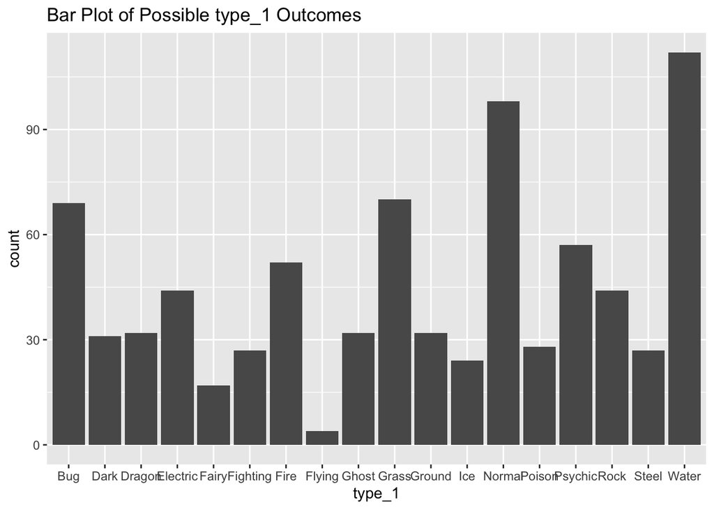

```r
ggplot(pokedex, aes(x=type_1)) +
  geom_bar() + ggtitle("Bar Plot of Possible type_1 Outcomes")
```

As can be seen from the bar plot above, there are 18 possible outcomes that a Pokemon can have for its `type_1`. It seems that the most abundant `type_1` class is `Water`, and the ratest class being `Flying`.

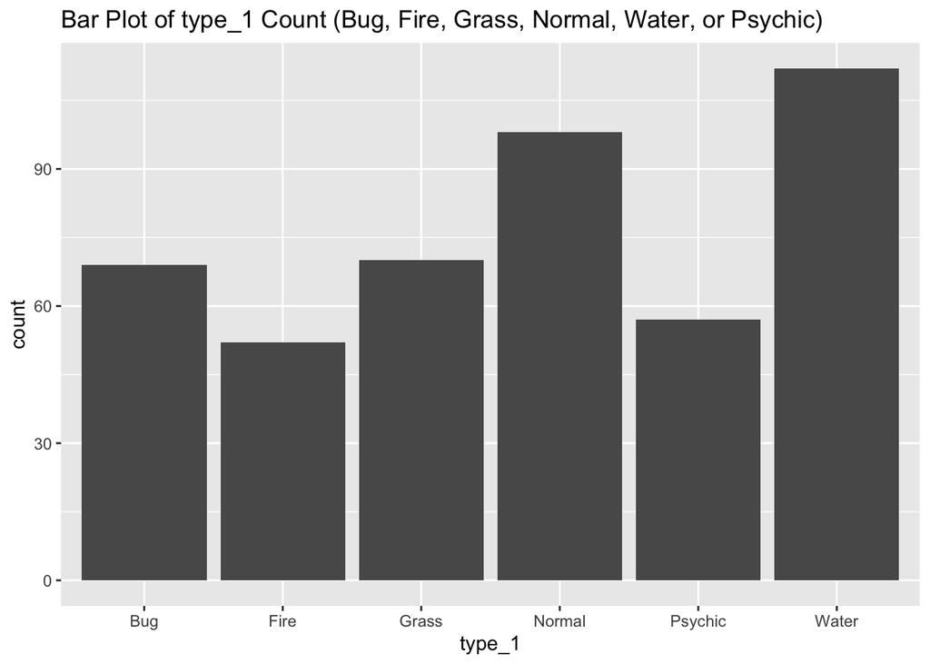

```r
pokedex_subset <- pokedex %>%
  filter(type_1 %in% c("Bug", "Fire", "Grass", "Normal", "Water", "Psychic"))
# We can check the filtered pokedex with a new barplot of the data
ggplot(pokedex_subset, aes(x=type_1)) +
  geom_bar() + ggtitle("Bar Plot of type_1 Count (Bug, Fire, Grass, Normal, Water, or Psychic)")
```

```r
# Factoring `type_1` and `legendary`
pokedex_subset$type_1 <- factor(pokedex_subset$type_1)
pokedex_subset$legendary <- factor(pokedex_subset$legendary)
```

### Exercise 3

Perform an initial split of the data. Stratify by the outcome variable. You can choose a proportion to use. Verify that your training and test sets have the desired number of observations.

Next, use *v*-fold cross-validation on the training set. Use 5 folds. Stratify the folds by `type_1` as well. *Hint: Look for a `strata` argument.* Why might stratifying the folds be useful?

## Solution 3:

```r
# sets the seed in order to reproduce results
set.seed(3435)

# creates an initial split of abalone data
pokedex_split <- initial_split(pokedex_subset, prop=0.80, strata=type_1)
pokedex_split
## <Training/Testing/Total>
## <364/94/458>

# creates the training split using 80% of the data
pokedex_train <- training(pokedex_split)
head(pokedex_train, n=5)
```

```
## # A tibble: 5 × 13
##       x name       type_1 type_2  total    hp attack defense sp_atk sp_def speed
##   <int> <chr>      <fct>  <chr>   <int> <int>  <int>   <int>  <int>  <int> <int>
## 1    10 Caterpie   Bug    ""        195    45     30      35     20     20    45
## 2    11 Metapod    Bug    ""        205    50     20      55     25     25    30
## 3    12 Butterfree Bug    "Flyin…   395    60     45      50     90     80    70
## 4    13 Weedle     Bug    "Poiso…   195    40     35      30     20     20    50
## 5    14 Kakuna     Bug    "Poiso…   205    45     25      50     25     25    35
## # … with 2 more variables: generation <int>, legendary <fct>
```

```r
# creates the test split using the remaining 20% of the data
pokedex_test <- testing(pokedex_split)
head(pokedex_test, n=5)
```

```
## # A tibble: 5 × 13
##       x name        type_1 type_2 total    hp attack defense sp_atk sp_def speed
##   <int> <chr>       <fct>  <chr>  <int> <int>  <int>   <int>  <int>  <int> <int>
## 1     3 VenusaurMe… Grass  "Pois…   625    80    100     123    122    120    80
## 2     9 BlastoiseM… Water  ""       630    79    103     120    135    115    78
## 3    15 Beedrill    Bug    "Pois…   395    65     90      40     45     80    75
## 4    15 BeedrillMe… Bug    "Pois…   495    65    150      40     15     80   145
## 5    20 Raticate    Normal ""       413    55     81      60     50     70    97
## # … with 2 more variables: generation <int>, legendary <fct>
```

```r
# v/k-fold cross-validation
pokedex_folds <- vfold_cv(pokedex_train, v = 5, strata = type_1)
pokedex_folds
## #  5-fold cross-validation using stratification
## # A tibble: 5 × 2
##   splits           id
##   <list>           <chr>
## 1 <split [289/75]> Fold1
## 2 <split [291/73]> Fold2
## 3 <split [291/73]> Fold3
## 4 <split [292/72]> Fold4
## 5 <split [293/71]> Fold5
```

### Exercise 4

Set up a recipe to predict `type_1` with `legendary`, `generation`, `sp_atk`, `attack`, `speed`, `defense`, `hp`, and `sp_def`.

- Dummy-code `legendary` and `generation`;
- Center and scale all predictors.

## Solution 4:

```r
pokedex_recipe <- recipe(type_1 ~ legendary + generation + sp_atk + attack + speed + defense + hp + sp_def, data=pokedex_train) %>%
  step_dummy(all_nominal_predictors()) %>%
  step_normalize(all_predictors())
pokedex_recipe
## Recipe
##
## Inputs:
##
##       role #variables
##    outcome          1
##  predictor          8
##
## Operations:
##
## Dummy variables from all_nominal_predictors()
## Centering and scaling for all_predictors()
```

### Exercise 5

We’ll be fitting and tuning an elastic net, tuning `penalty` and `mixture` (use `multinom_reg` with the `glmnet` engine).

Set up this model and workflow. Create a regular grid for `penalty` and `mixture` with 10 levels each; `mixture` should range from 0 to 1. For this assignment, we’ll let `penalty` range from -5 to 5 (it’s log-scaled).

How many total models will you be fitting when you fit these models to your folded data?

## Solution 5:

```r
pokedex_spec <-
  multinom_reg(penalty = tune(), mixture = 0) %>%
  set_engine("glmnet")

pokedex_workflow <- workflow() %>%
  add_recipe(pokedex_recipe) %>%
  add_model(pokedex_spec)

pokedex_grid <- grid_regular(penalty(range = c(-5, 5)), levels = 10)
pokedex_grid
```

```
## # A tibble: 10 × 1
##          penalty
##            <dbl>
##  1      0.00001
##  2      0.000129
##  3      0.00167
##  4      0.0215
##  5      0.278
##  6      3.59
##  7     46.4
##  8    599.
##  9   7743.
## 10 100000
```

### Exercise 6

Fit the models to your folded data using `tune_grid()`.

Use `autoplot()` on the results. What do you notice? Do larger or smaller values of `penalty` and `mixture` produce better accuracy and ROC AUC?

## Solution 6:

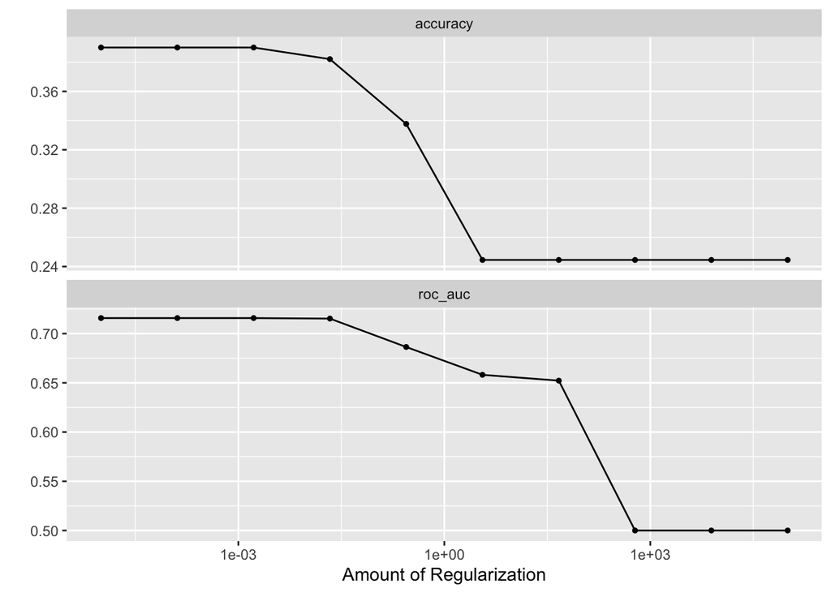

```r
tune_res <- tune_grid(
  pokedex_workflow,
  resamples = pokedex_folds,
  grid = pokedex_grid
)
autoplot(tune_res)
```

### Exercise 7

Use `select_best()` to choose the model that has the optimal `roc_auc`. Then use `finalize_workflow()`, `fit()`, and `augment()` to fit the model to the training set and evaluate its performance on the testing set.